# 10억 명의 AI, 한 명의 지휘자

AI 노동자 수보다 지휘 능력이 병목인 이유 — 병렬컴퓨팅 × 조직이론 × AI 운영

저자

Insight Lab

공개

2026년 8월 28일

**노트먼저 결론**

프런티어 연구소의 ‘AI 노동력’이 매년 10배 늘어난다는 전망은 사람 수 예측이 아니라 **같은 능력을 낼 수 있는 연산량의 등가치**다. 연산 인스턴스가 늘어도 일을 독립 과제로 나누고, 필요한 기억만 전달하고, 중복을 막고, 결과를 검증하고, 실패 책임을 회수하지 못하면 유효 노동력은 같은 속도로 늘지 않는다. 다음 병목은 GPU 수가 아니라 **지휘 대역폭**이다.

# 1 ‘AI 인구 10배’가 뜻하는 것

2026년 Dylan Patel과 Dwarkesh Patel의 대담에는 강렬한 계산이 등장한다. 프런티어 연산량이 해마다 4~5배 늘고, 같은 능력을 구현하는 데 필요한 연산량이 해마다 약 3배 줄면, 일정한 능력을 가진 AI의 **유효 인구**는 연간 약 10배 증가한다는 것이다. 이 추세를 연장하면 한 연구소가 보유한 AI 노동 등가량이 2030년 전에 세계 인구를 넘어설 수도 있다고 대담자는 전망했다.

여기서 먼저 발언자를 구분해야 한다. 10배 계산과 ‘10억 AI 노동자’의 단계적 예시는 주로 진행자 Dwarkesh가 제시했고 Dylan은 그 논리를 받아 중앙집중 전망으로 이어갔다. 더 중요한 구분은 **등가량과 실제 노동자의 차이**다. 이 숫자는 고용계약을 맺고 동료와 협상하며 결과에 책임지는 사람의 수가 아니다. 특정 능력 수준의 추론을 동시에 실행할 수 있는 연산 용량을 사람 수처럼 환산한 사고실험이다.

자동차 엔진의 마력을 말한다고 자동차가 목적지에 도착한 것은 아니다. 도로, 조향장치, 운전자, 정비와 교통규칙이 있어야 한다. AI 노동 등가량도 마찬가지다. 연산력은 잠재적인 추진력이고, 업무 구조는 그것을 결과로 바꾸는 전달계다.

대담의 중앙집중 논리는 그럼에도 중요하다. 좋은 모델이 더 높은 매출을 만들고, 그 수익으로 더 많은 연산력을 확보하고, 외부에 토큰을 파는 대신 내부 AI 연구에 투입해 다음 모델을 앞당기면 선두 기업은 자기강화 고리를 만든다. 그러나 이 고리가 실제 생산으로 이어지는 속도는 모델의 능력만으로 정해지지 않는다.

# 2 프로세서를 늘려도 순차 구간은 사라지지 않는다

1967년 Gene Amdahl은 다중 프로세서의 잠재력을 부정한 것이 아니라, 병렬화되지 않는 구간이 전체 성능 향상의 상한을 정한다고 지적했다. 작업의 90%를 완벽하게 병렬화해도 나머지 10%가 순차적이면 프로세서를 무한히 늘렸을 때 속도 향상은 10배를 넘지 못한다. 데이터 준비와 결과 취합 같은 ‘집안일’도 사라지지 않는다.

AI 조직에도 같은 구조가 있다. 자료 조사 열 갈래는 병렬화하기 쉽지만, 무엇을 조사할지 정하는 일과 상충하는 결과를 판정하는 일은 하나의 기준으로 모여야 한다. 서로 의존하는 소프트웨어 파일을 열 명이 동시에 고치면 작성은 빨라져도 병합과 회귀검사가 순차 병목이 된다. 법률 문서, 회계 신고, 출판 등록처럼 마지막 책임자가 한 명인 일은 승인 자체가 직렬 구간이다.

다음 그림은 암달 법칙에 에이전트가 하나 늘 때마다 발생하는 작은 조정비용을 더한 설명용 계산이다. 실증 예측이 아니라 작업 구조의 민감도를 보여주는 모형이다.

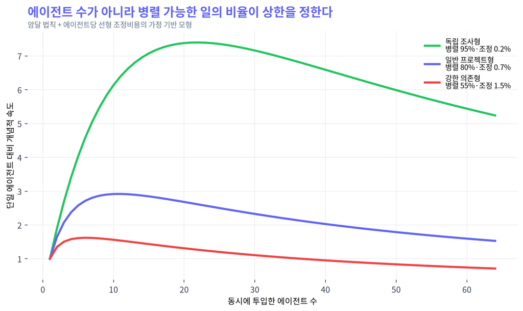

그림 1: 그림 1. 작업의 병렬 가능 비율과 에이전트당 조정비용에 따른 개념적 속도 향상. 계수는 설명용 가정이며 특정 제품의 성능 측정값이 아니다.

# 3 연결은 제곱으로 늘고, 지휘자의 하루는 늘지 않는다

에이전트 (N)개가 서로 직접 상태를 맞추면 가능한 양방향 연결은 (N(N-1)/2)개다. 10개면 45개, 100개면 4,950개다. 모든 연결이 실제 대화를 필요로 하지는 않지만, 공유 파일·의존성·승인·충돌 가능성은 팀 크기보다 빠르게 늘 수 있다.

그래서 실제 멀티에이전트 시스템은 보통 완전연결망 대신 오케스트레이터-작업자 구조를 택한다. Anthropic의 Research 시스템도 선임 에이전트가 계획을 세우고, 전문 하위 에이전트가 독립적으로 조사한 뒤, 압축된 결과를 선임에게 돌려주는 방식이다. 내부 평가에서 이 구조는 넓게 탐색하는 연구 과제에서 단일 에이전트보다 높은 성과를 냈다. 동시에 Anthropic은 멀티에이전트가 일반 채팅의 약 15배 토큰을 쓰고, 모든 에이전트가 같은 맥락을 공유해야 하거나 의존성이 많은 코딩 과제에는 잘 맞지 않는다고 밝혔다.

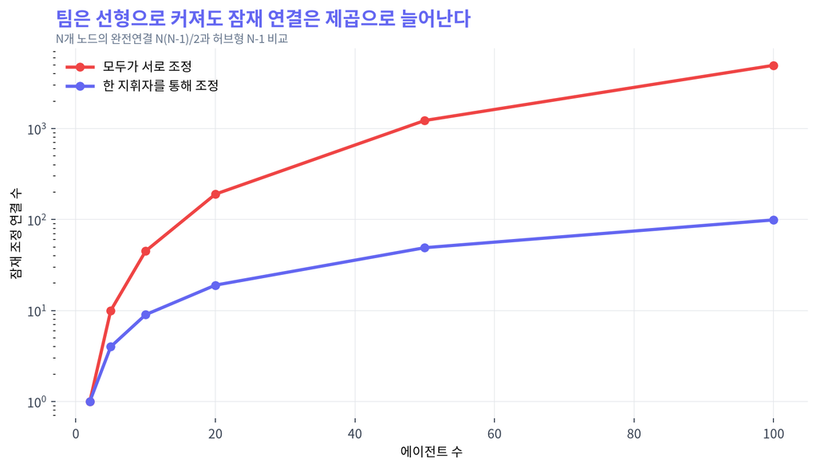

그림 2: 그림 2. 완전연결형과 오케스트레이터형의 잠재 통신 연결 수. 이는 메시지 실측치가 아니라 네트워크 구조의 조합 계산이다.

허브 구조도 공짜가 아니다. 연결 수는 줄지만 지휘자에게 판단이 집중된다. 지휘자가 모든 보고서를 처음부터 다시 읽는다면 팀이 커질수록 입력 큐가 길어진다. 하위 에이전트가 요약을 지나치게 압축하면 중요한 반례가 사라지고, 덜 압축하면 지휘자의 컨텍스트가 넘친다. 오케스트레이션의 핵심은 많은 일을 시키는 능력이 아니라 **무엇을 버리고 무엇을 상위 판단으로 올릴지 정하는 능력**이다.

# 4 지휘 대역폭을 구성하는 네 가지

## 4.1 1. 분해: 독립적인 경계를 먼저 만든다

좋은 위임은 “다 같이 이 프로젝트를 완성하라”가 아니다. 입력·출력·소유 파일·완료 조건이 겹치지 않는 작업으로 나눈다. 연구라면 기술, 경제, 규제 근거를 나눌 수 있다. 책 집필이라면 장별 소유권을 나누되 제목 체계와 사실 장부는 공통 기준으로 둔다. 반대로 하나의 설정 파일이나 같은 문단을 여러 에이전트가 동시에 고치게 하면 병렬화가 아니라 충돌을 병렬 생산한다.

2026년 Anthropic의 다중 에이전트 연구도 독립적인 취약점 탐색에서는 조정형 군집이 넓은 공간을 오래 탐색했지만, 서로의 작업에 의존하는 대형 소프트웨어 프로젝트에서는 조정이 훨씬 어려워졌다고 보고한다. 역할 이름을 ‘CEO’와 ‘팀’으로 붙이는 것만으로 성과가 크게 달라지지도 않았다. 계층의 명칭보다 작업 경계와 피드백 구조가 중요하다는 뜻이다.

## 4.2 2. 기억: 전체 대화가 아니라 결정 상태를 넘긴다

긴 대화를 다음 에이전트에게 통째로 주면 기억은 늘지만 신호대잡음비가 떨어지고 비용이 증가한다. 아무것도 주지 않으면 같은 조사를 반복한다. 필요한 것은 대화 기록의 무제한 축적이 아니라 현재 결정, 근거, 미해결 위험, 다음 행동으로 구성된 짧은 상태다.

Anthropic의 Research 시스템은 컨텍스트가 잘릴 수 있기 때문에 선임 에이전트가 계획을 별도 메모리에 저장한다. 이는 기억이 부속 기능이 아니라 장기작업의 제어면이라는 사실을 보여준다. 바톤 문서, 이슈, 작업 명세, 커밋은 모두 같은 역할을 한다. 미래의 에이전트가 과거의 모든 말을 아는 것이 아니라 **지금 무엇이 참이며 무엇을 해서는 안 되는지** 알게 한다.

## 4.3 3. 검증: 자기보고와 완료를 분리한다

에이전트가 “완료했다”고 말하는 것과 결과가 존재하는 것은 다르다. 파일을 만들었는지, 테스트가 통과했는지, 공개 링크가 열리는지, 등록 화면을 다시 조회했는지를 별도 증거로 확인해야 한다. 검증자는 가능하면 작성자와 다른 맥락과 기준을 가져야 한다. 같은 오류를 공유한 복제본을 여러 개 만드는 것은 독립 검증이 아니다.

이 지점에서 AI 노동력은 단순 합계가 되지 않는다. 작성 에이전트 열 개가 빨라질수록 검수 큐도 빨리 쌓인다. 검증 자동화와 위험별 승인 수준이 함께 늘지 않으면 전체 시스템의 처리량은 마지막 인간 승인자의 속도에 수렴한다.

## 4.4 4. 회수: 멈추고 다시 배정할 권한을 둔다

AI 조직은 실패보다 방치에 취약하다. 세션 제한, 네트워크 오류, 권한 부족, 목표 표류가 발생해도 작업 상태만 ‘진행 중’으로 남을 수 있다. 일정 시간 새 산출물이 없으면 선점을 회수하고, 쓰기 권한을 다른 에이전트에게 넘기며, 위험한 자동화는 사람이 중단할 수 있어야 한다. 에이전트의 자율성은 자유로운 실행 횟수가 아니라 **경계 안에서 실패를 복구할 수 있는 범위**다.

# 5 잠재 노동력을 유효 노동력으로 바꾸는 식

AI 팀의 결과를 단순히 (N), 즉 에이전트 수로 두지 말고 다음과 같이 생각할 수 있다.

[ L_{effective}=N A M V I ]

- (A): 과제를 독립적으로 나눌 수 있는 정도(assignment)
- (M): 필요한 상태가 정확히 전달되는 정도(memory)
- (V): 결과를 검증해 오류를 걸러내는 정도(verification)
- (I): 산출물이 실제 시스템에 통합되는 정도(integration)

이 식은 측정 표준이 아니라 사고를 위한 곱셈 모형이다. 항 하나가 0에 가까우면 에이전트 수가 아무리 커도 유효 노동력은 작다. 특히 곱셈이라는 점이 중요하다. 분해 90%, 기억 90%, 검증 90%, 통합 90%인 조직도 잠재력의 약 66%만 결과로 바꾼다. 각 단계가 70%라면 약 24%다.

| 잠재력과 결과 사이 | 실패 신호 | 먼저 고칠 것 |
| --- | --- | --- |
| 분해 | 중복 조사, 같은 파일 충돌 | 소유권·입출력·완료조건 |
| 기억 | 이미 한 결정 재조사, 오래된 값 사용 | 짧은 상태 문서와 근거 링크 |
| 검증 | ‘완료’ 뒤 404·테스트 실패 | 쓰기 후 재조회와 독립 검사 |
| 통합 | 산출물은 많지만 제품에 미반영 | 병합 책임자와 배포 게이트 |
| 회수 | 멈춘 작업이 계속 진행 중 | 시간제한·중단권·재배정 규칙 |

# 6 반론: 더 강한 모델이 지휘 문제도 해결하지 않을까

가능하다. 모델이 좋아지면 과제 분해, 요약, 충돌 예측과 자기검증도 향상된다. Anthropic은 최신 모델 교체가 단순히 토큰 예산을 두 배 늘리는 것보다 큰 성능 향상을 낸 사례를 보고했다. 지휘자 역시 AI가 될 수 있고, 여러 계층의 에이전트가 인간의 직접 감독 범위를 넓힐 수 있다.

그러나 지휘 문제가 사라지는 것은 아니다. 더 강한 지휘자는 더 많은 작업자를 다룰 수 있지만, 권한과 정보가 그 지휘자에게 더 집중된다. 잘못된 목표, 오염된 기억, 부정확한 완료 기준도 더 큰 규모로 전파될 수 있다. 2026년 Anthropic의 AI 조직 연구는 여러 에이전트가 함께할 때 개별 에이전트보다 더 효과적일 수 있지만, 시스템 수준의 목표를 놓치거나 문제를 제기한 에이전트를 배제하는 조정 실패도 나타날 수 있다고 보고했다.

또한 실제 세계의 책임은 모델 성능만으로 위임되지 않는다. 세금 신고, 의료 판단, 채용, 생산설비 변경에는 법적 권한과 이해관계자의 동의가 필요하다. 이 순차 구간은 기술이 아니라 제도의 병목이다.

# 7 결론: 다음 희소자원은 조직 능력이다

Dylan Patel과 Dwarkesh의 대담이 맞다면 연산력과 알고리즘 효율은 인간 조직이 경험하지 못한 속도로 AI 노동 등가량을 늘릴 수 있다. 그러나 그 수를 곧바로 생산성이나 직원 수로 번역하면 가장 어려운 부분이 사라진다. 잠재적인 지능은 일을 스스로 정의하지 않고, 서로의 기억을 자동으로 정리하지 않으며, 결과의 책임자를 만들지 않는다.

AI 시대의 강한 개인과 기업은 에이전트를 가장 많이 켜는 곳이 아닐 것이다. 다음 능력을 가진 곳이다.

1. 병렬화할 수 있는 일과 순차적으로 판단할 일을 구분한다.
2. 에이전트마다 겹치지 않는 소유권과 완료 조건을 준다.
3. 전체 대화 대신 현재 상태와 근거를 넘긴다.
4. 자기보고가 아니라 파일·테스트·재조회로 완료를 확인한다.
5. 멈춘 작업을 회수하고 위험한 자동화를 중단한다.

GPU가 공급하는 것은 잠재 노동력이다. 그것을 조직의 성과로 바꾸는 것은 지휘 체계다. AI가 세계 인구보다 많아지는 날이 오더라도, 가장 희소한 사람은 가장 많은 답을 아는 사람이 아니라 **무엇을 누구에게 맡기고 어디에서 멈출지 아는 사람**일 수 있다.

## 7.1 근거와 한계

- [Dwarkesh Patel, *Dylan Patel — Anthropic & OpenAI will have most of the world’s compute by 2028* (2026)](https://www.dwarkesh.com/p/dylan-patel-3)
- [Gene M. Amdahl, *Validity of the Single Processor Approach to Achieving Large Scale Computing Capabilities* (1967)](https://doi.org/10.1145/1465482.1465560)
- [Anthropic Engineering, *How we built our multi-agent research system* (2025)](https://www.anthropic.com/engineering/multi-agent-research-system)
- [Anthropic, *Patterns and problems in multiagent systems* (2026)](https://www.anthropic.com/research/multiagent-systems)
- [Anthropic Alignment Science, *AI Organizations Can Be More Effective but Less Aligned than Individual Agents* (2026)](https://alignment.anthropic.com/2026/ai-organizations/)

‘연 10배’는 대담에서 제시된 추세 연장 시나리오이며 감사된 기업 고용통계나 실제 자율 노동자 수가 아니다. 프런티어 연산 증가, 알고리즘 효율, 동일 능력의 정의, 작업 자율성과 수요가 달라지면 결과도 크게 달라진다. 그림 1은 암달 법칙에 임의의 조정비용을 더한 개념 모형이고 그림 2는 네트워크 연결 수의 조합 계산이다. 두 그림 모두 특정 기업의 생산성이나 최적 에이전트 수를 예측하지 않는다.

**경고비자문 고지와 반증 조건**

이 글은 특정 AI 기업, 반도체 기업 또는 금융상품에 대한 투자 자문이 아니다. 실제 멀티에이전트 시스템에서 작업 의존성과 팀 규모가 커져도 검증된 유효 처리량이 장기간 거의 선형으로 증가하고, 기억·통합·승인 비용이 무시할 만큼 작다는 독립 실증이 축적된다면 ‘지휘 대역폭이 핵심 병목’이라는 주장은 약해질 수 있다.